# BIOL432_Assignment1

SiruiZHAO

2023-01-11

[my GitHub repository](https://github.com/siruiZHAO/BIOL432_Assignment1)

First, load library

```r
library(ggplot2)
library(dplyr)
```

Then, we need to source two R scripts.

1). dataGenerato.R generate 4 varuables, organism, limb width, limb length and observer, and combine them into a data frame.

2). volumeEstimato.R add one variable called limb volume into the data frame. The limb volume calculated from the v = pi * (limb_width/2)^2 * limb_length

```r
source("dataGenerato.R", local = knitr::knit_global())
source("volumeEstimato.R", local = knitr::knit_global())
```

```
## 'data.frame':    100 obs. of  4 variables:
##  $ organism   : chr  "\"Bos gaurus\"" "\"Antelope cervicapra\"" "\"Gazella bennettii\"" "\"Boselaphus tragocamelus\"" ...
##  $ Limb_width : num  3.01 2.78 3.12 3.47 1.2 ...
##  $ Limb_length: num  17.6 55.6 51.7 46.7 57.7 ...
##  $ Observer   : chr  "\"Charles Darwin\"" "\"Charles Darwin\"" "\"Charles Darwin\"" "\"Charles Darwin\"" ...
```

1. Load the revised measurements.csv and library

```r
mydata <- read.csv("measurements.csv")
```

2. Use dplyr to sort the data by species, then by observer, then by limb volume

```r
mydata <- mydata %>% #use pipe in dplyr
  arrange(organism, Observer, limb_volume) # use arrange to sort column in order
head(mydata)
```

```
##                organism Limb_width Limb_length         Observer limb_volume
## 1 "Antelope cervicapra"   3.062553    12.31966 "Charles Darwin"    90.75192
## 2 "Antelope cervicapra"   2.779865    24.60835 "Charles Darwin"   149.35499
## 3 "Antelope cervicapra"   4.204600    22.03541 "Charles Darwin"   305.95692
## 4 "Antelope cervicapra"   2.784150    55.59689 "Charles Darwin"   338.47434
## 5 "Antelope cervicapra"   3.606322    37.04045 "Charles Darwin"   378.35125
## 6 "Antelope cervicapra"   3.700756    62.28123 "Charles Darwin"   669.92770
```

3. Create a table showing the average volume for each species

```r
avg_volume <- mydata %>%     #select data frame
  group_by(organism) %>%   #group rows by column values in the DataFrame
  summarise(mean_volum = mean(limb_volume)) #calculate mean of limb volume
avg_volume
```

```
## # A tibble: 5 × 2
##   organism                      mean_volum
##   <chr>                              <dbl>
## 1 "\"Antelope cervicapra\""           386.
## 2 "\"Bos gaurus\""                    267.
## 3 "\"Boselaphus tragocamelus\""       226.
## 4 "\"Canis lupus\""                   306.
## 5 "\"Gazella bennettii\""             303.
```

4. Create a table showing the number of observations (i.e. rows) for each combination of species and observer.

```r
observation <- mydata %>%     #select data frame
  group_by(organism, Observer) %>%  #group rows by two column values
  summarise(observations = n(), .group = "drop") %>%  #count frequency
  as.data.frame()
observation
```

```
##                     organism         Observer observations .group
## 1      "Antelope cervicapra" "Charles Darwin"            7   drop
## 2      "Antelope cervicapra"  "Gregor Mendel"            6   drop
## 3      "Antelope cervicapra"   "Robert Hooke"            7   drop
## 4               "Bos gaurus" "Charles Darwin"            7   drop
## 5               "Bos gaurus"  "Gregor Mendel"            7   drop
## 6               "Bos gaurus"   "Robert Hooke"            6   drop
## 7  "Boselaphus tragocamelus" "Charles Darwin"            6   drop
## 8  "Boselaphus tragocamelus"  "Gregor Mendel"            7   drop
## 9  "Boselaphus tragocamelus"   "Robert Hooke"            7   drop
## 10             "Canis lupus" "Charles Darwin"            6   drop
## 11             "Canis lupus"  "Gregor Mendel"            7   drop
## 12             "Canis lupus"   "Robert Hooke"            7   drop
## 13       "Gazella bennettii" "Charles Darwin"            7   drop
## 14       "Gazella bennettii"  "Gregor Mendel"            6   drop
## 15       "Gazella bennettii"   "Robert Hooke"            7   drop
```

5. Create a single box plot (or similar) to compare key features of the distributions of volumes for each species.

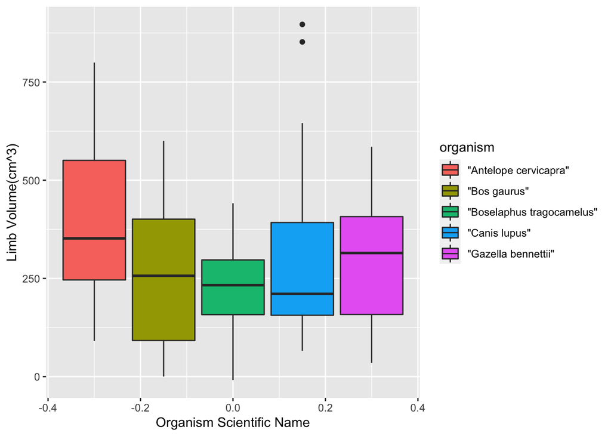

```r
#use ggplot2 to create box plot
plot1 <- ggplot(mydata, aes(y = limb_volume, fill = organism)) + geom_boxplot() + labs(x = "Organism Scientific Name", y = "Limb Volume(cm^3)")
plot1
```

6. Create a multi-panel plot showing frequency histograms showing the distribution of limb volume for each species. Note that this may require you to add code to you R markdown file to change the data from the wide to long format.

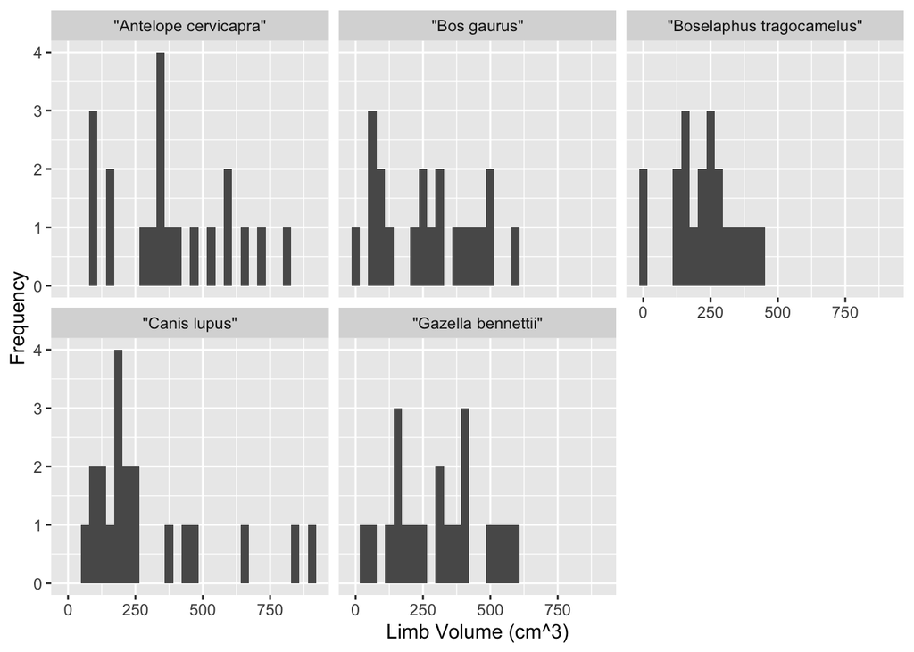

```r
#use facet_wrap() in ggplot2 to create multi-panel plot
ggplot(mydata, aes(x = limb_volume)) +
  geom_histogram() +
  facet_wrap(vars(organism)) + labs(x = "Limb Volume (cm^3)", y = "Frequency")
```

Thanks!